# RNA-seq Analysis in R

Annotation and Visualisation of RNA-seq results

Stephane Ballereau, Mark Dunning, Oscar Rueda, Ashley Sawle

Last modified: 03 May 2017

**Original Authors: Belinda Phipson, Anna Trigos, Matt Ritchie, Maria Doyle, Harriet Dashnow, Charity Law** Based on the course [RNAseq analysis in R](http://combine-australia.github.io/2016-05-11-RNAseq/) delivered on May 11/12th 2016

Before starting this section, we will make sure we have all the relevant objects from the Differential Expression analysis present.

```r
suppressPackageStartupMessages(library(edgeR))
load("Robjects/DE.Rdata")
```

# Overview

- Visualising DE results
- Getting annotation
- Retrieving gene models
- Exporting browser traecks
- Visualising results with respect to genomic location

We have a list of significantly differentially expressed genes, but the only annotation we can see is the Entrez Gene ID, which is not very informative.

```r
results <- as.data.frame(topTags(lrt.BvsL,n = Inf))
results
```

|  | logFC | logCPM | LR | PValue | FDR |
| --- | --- | --- | --- | --- | --- |
| 110308 | -8.940578 | 10.26429709 | 24.89789 | 6.044844e-07 | 0.0004377961 |
| 50916 | -8.636503 | 5.74978133 | 24.80037 | 6.358512e-07 | 0.0004377961 |
| 12293 | -8.362247 | 6.79478831 | 24.68526 | 6.749827e-07 | 0.0004377961 |
| 56069 | -8.419433 | 6.12437709 | 24.41532 | 7.764861e-07 | 0.0004377961 |
| 24117 | -9.290691 | 6.75716310 | 24.32506 | 8.137331e-07 | 0.0004377961 |
| 12818 | -8.216790 | 8.17224720 | 24.24233 | 8.494462e-07 | 0.0004377961 |
| 22061 | -8.034712 | 7.25537036 | 24.16987 | 8.820135e-07 | 0.0004377961 |
| 12797 | -9.001419 | 9.91079515 | 24.12854 | 9.011487e-07 | 0.0004377961 |
| 50706 | -7.697022 | 10.80962881 | 24.06926 | 9.293193e-07 | 0.0004377961 |
| 237979 | -8.167451 | 5.21592065 | 24.03528 | 9.458678e-07 | 0.0004377961 |

[output cut: 990 more lines]

```r
dim(results)
```

```
[1] 15804     5
```

`edgeR` provides a function `plotSmear` that allows us to visualise the results of a DE analysis. In a similar manner to the [*MA-plot* for microarray data](https://en.wikipedia.org/wiki/MA_plot), this plot shows the log-fold change against log-counts per million, with DE genes highlighted:

```r
summary(de <- decideTestsDGE(lrt.BvsL))
```

```
   [,1]
-1  2957
0  11232
1   1615
```

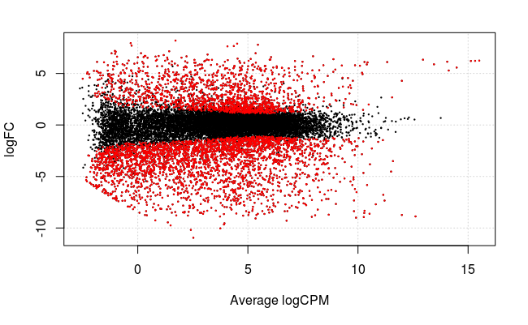

```r
detags <- rownames(dgeObj)[as.logical(de)]
plotSmear(lrt.BvsL, de.tags=detags)
```

However, on such a plot it would be nice to add labels to highlight the genes with most evidence for being DE, or our favourite genes. To perform such a task we need to map between the identifiers we have in the `edgeR` output and more familiar names.

Finally, we will look at sophisticated visualisations that allow us to incorporate information about the structure of a gene, level of sequencing coverage.

## Adding annotation to the edgeR results

There are a number of ways to add annotation, but we will demonstrate how to do this using the *org.Mm.eg.db* package. This package is one of several *organism-level* packages which are re-built every 6 months. These packages are listed on the [annotation section](http://bioconductor.org/packages/release/BiocViews.html#___AnnotationData) of the Bioconductor, and are installed in the same way as regular Bioconductor packages. An alternative approach is to use `biomaRt`, an interface to the [BioMart](http://www.biomart.org/) resource. BioMart is much more comprehensive, but the organism packages fit better into the Bioconductor workflow.

```r
source("http://www.bioconductor.org/biocLite.R")
biocLite("org.Mm.eg.db")
# For Human
biocLite("org.Hs.eg.db")
```

The packages are larger in size that Bioconductor software pacakges, but essentially they are databases that can be used to make *offline* queries.

```r
library(org.Mm.eg.db)
```

First we need to decide what information we want. In order to see what we can extract we can run the `columns` function on the annotation database.

```r
columns(org.Mm.eg.db)
```

```
 [1] "ACCNUM"       "ALIAS"        "ENSEMBL"      "ENSEMBLPROT"  "ENSEMBLTRANS" "ENTREZID"     "ENZYME"       "EVIDENCE"     "EVIDENCEALL"  "GENENAME"
[11] "GO"           "GOALL"        "IPI"          "MGI"          "ONTOLOGY"     "ONTOLOGYALL"  "PATH"         "PFAM"         "PMID"         "PROSITE"
[21] "REFSEQ"       "SYMBOL"       "UNIGENE"      "UNIPROT"
```

We are going to filter the database by a key or set of keys in order to extract the information we want. Valid names for the key can be retrieved with the `keytypes` function.

```r
keytypes(org.Mm.eg.db)
```

```
 [1] "ACCNUM"       "ALIAS"        "ENSEMBL"      "ENSEMBLPROT"  "ENSEMBLTRANS" "ENTREZID"     "ENZYME"       "EVIDENCE"     "EVIDENCEALL"  "GENENAME"
[11] "GO"           "GOALL"        "IPI"          "MGI"          "ONTOLOGY"     "ONTOLOGYALL"  "PATH"         "PFAM"         "PMID"         "PROSITE"
[21] "REFSEQ"       "SYMBOL"       "UNIGENE"      "UNIPROT"
```

We should see `ENTREZID`, which is the type of key we are going to use in this case. If we are unsure what values are acceptable for the key, we can check what keys are valid with `keys`

```r
keys(org.Mm.eg.db, keytype="ENTREZID")[1:10]
```

```
 [1] "11287" "11298" "11302" "11303" "11304" "11305" "11306" "11307" "11308" "11350"
```

It is a useful sanity check to make sure that the keys you want to use are all valid. We could use `%in%` in this case.

```r
## Build up the query step-by-step
my.keys <- c("50916", "110308","12293")
my.keys %in% keys(org.Mm.eg.db, keytype="ENTREZID")
```

```
[1] TRUE TRUE TRUE
```

```r
all(my.keys %in% keys(org.Mm.eg.db, keytype="ENTREZID"))
```

```
[1] TRUE
```

Let’s build up the query step by step.

```r
## to be filled-in interactively during the class.
select(org.Mm.eg.db,
```

To annotate our results, we definitely want gene symbols and perhaps the full gene name. Let’s build up our annotation information in a separate data frame using the `select` function.

```r
ann <- select(org.Mm.eg.db,keys=rownames(results),columns=c("ENTREZID","SYMBOL","GENENAME"))
# Have a look at the annotation
ann
```

| ENTREZID | SYMBOL | GENENAME |
| --- | --- | --- |
| 110308 | Krt5 | keratin 5 |
| 50916 | Irx4 | Iroquois related homeobox 4 (Drosophila) |
| 12293 | Cacna2d1 | calcium channel, voltage-dependent, alpha2/delta subunit 1 |
| 56069 | Il17b | interleukin 17B |
| 24117 | Wif1 | Wnt inhibitory factor 1 |
| 12818 | Col14a1 | collagen, type XIV, alpha 1 |
| 22061 | Trp63 | transformation related protein 63 |
| 12797 | Cnn1 | calponin 1 |
| 50706 | Postn | periostin, osteoblast specific factor |
| 237979 | Sdk2 | sidekick cell adhesion molecule 2 |

[output cut: 990 more lines]

Let’s double check that the `ENTREZID` column matches exactly to our `results` rownames.

```r
table(ann$ENTREZID==rownames(results))
```

```
 TRUE
15804
```

We can bind in the annotation information to the `results` data frame. (Please note that if the `select` function returns a 1:many mapping then you can’t just append the annotation to the fit object.)

```r
results.annotated <- cbind(results, ann)
results.annotated
```

|  | logFC | logCPM | LR | PValue | FDR | ENTREZID | SYMBOL | GENENAME |
| --- | --- | --- | --- | --- | --- | --- | --- | --- |
| 110308 | -8.940578 | 10.26429709 | 24.89789 | 6.044844e-07 | 0.0004377961 | 110308 | Krt5 | keratin 5 |
| 50916 | -8.636503 | 5.74978133 | 24.80037 | 6.358512e-07 | 0.0004377961 | 50916 | Irx4 | Iroquois related homeobox 4 (Drosophila) |
| 12293 | -8.362247 | 6.79478831 | 24.68526 | 6.749827e-07 | 0.0004377961 | 12293 | Cacna2d1 | calcium channel, voltage-dependent, alpha2/delta subunit 1 |
| 56069 | -8.419433 | 6.12437709 | 24.41532 | 7.764861e-07 | 0.0004377961 | 56069 | Il17b | interleukin 17B |
| 24117 | -9.290691 | 6.75716310 | 24.32506 | 8.137331e-07 | 0.0004377961 | 24117 | Wif1 | Wnt inhibitory factor 1 |
| 12818 | -8.216790 | 8.17224720 | 24.24233 | 8.494462e-07 | 0.0004377961 | 12818 | Col14a1 | collagen, type XIV, alpha 1 |
| 22061 | -8.034712 | 7.25537036 | 24.16987 | 8.820135e-07 | 0.0004377961 | 22061 | Trp63 | transformation related protein 63 |
| 12797 | -9.001419 | 9.91079515 | 24.12854 | 9.011487e-07 | 0.0004377961 | 12797 | Cnn1 | calponin 1 |
| 50706 | -7.697022 | 10.80962881 | 24.06926 | 9.293193e-07 | 0.0004377961 | 50706 | Postn | periostin, osteoblast specific factor |
| 237979 | -8.167451 | 5.21592065 | 24.03528 | 9.458678e-07 | 0.0004377961 | 237979 | Sdk2 | sidekick cell adhesion molecule 2 |

[output cut: 990 more lines]

We can save the results table using the `write.csv` function, which writes the results out to a csv file that you can open in excel.

```r
write.csv(results.annotated,file="B.PregVsLacResults.csv",row.names=FALSE)
```

**A note about deciding how many genes are significant**: In order to decide which genes are differentially expressed, we usually take a cut-off of 0.05 on the adjusted p-value, NOT the raw p-value. This is because we are testing more than 15000 genes, and the chances of finding differentially expressed genes is very high when you do that many tests. Hence we need to control the false discovery rate, which is the adjusted p-value column in the results table. What this means is that if 100 genes are significant at a 5% false discovery rate, we are willing to accept that 5 will be false positives. Note that the `decideTests` function displays significant genes at 5% FDR.